# Exploration GoBike 2017

## Preliminary Wrangling

```python
# import all packages and set plots to be embedded inline
import numpy as np
import pandas as pd
import matplotlib.pyplot as plt
import matplotlib.image as mpimg
import seaborn as sb

%matplotlib inline

import seaborn as sb
```

### Gather Data

```python
# Import CSV file
trip_data = pd.read_csv('2017-fordgobike-tripdata.csv')

# Initial inspection
trip_data.sample(3)
```

|  | duration_sec | start_time | end_time | start_station_id | start_station_name | start_station_latitude | start_station_longitude | end_station_id | end_station_name | end_station_latitude | end_station_longitude | bike_id | user_type |
| --- | --- | --- | --- | --- | --- | --- | --- | --- | --- | --- | --- | --- | --- |
| 367271 | 921 | 2017-09-08 14:13:41.2050 | 2017-09-08 14:29:02.4580 | 163 | Lake Merritt BART Station | 37.797320 | -122.265320 | 194 | Lakeshore Ave at Trestle Glen Rd | 37.811081 | -122.243268 | 114 | Customer |
| 21398 | 882 | 2017-12-19 18:31:37.3500 | 2017-12-19 18:46:20.0380 | 58 | Market St at 10th St | 37.776619 | -122.417385 | 126 | Esprit Park | 37.761634 | -122.390648 | 3445 | Subscriber |
| 196081 | 823 | 2017-10-27 15:49:13.7570 | 2017-10-27 16:02:56.9430 | 81 | Berry St at 4th St | 37.775880 | -122.393170 | 5 | Powell St BART Station (Market St at 5th St) | 37.783899 | -122.408445 | 1901 | Subscriber |

### Assess Data

```python
trip_data.info()
```

```
<class 'pandas.core.frame.DataFrame'>
RangeIndex: 519700 entries, 0 to 519699
Data columns (total 13 columns):
 #   Column                   Non-Null Count   Dtype
---  ------                   --------------   -----
 0   duration_sec             519700 non-null  int64
 1   start_time               519700 non-null  object
 2   end_time                 519700 non-null  object
 3   start_station_id         519700 non-null  int64
 4   start_station_name       519700 non-null  object
 5   start_station_latitude   519700 non-null  float64
 6   start_station_longitude  519700 non-null  float64
 7   end_station_id           519700 non-null  int64
 8   end_station_name         519700 non-null  object
 9   end_station_latitude     519700 non-null  float64
 10  end_station_longitude    519700 non-null  float64
 11  bike_id                  519700 non-null  int64
 12  user_type                519700 non-null  object
dtypes: float64(4), int64(4), object(5)
memory usage: 51.5+ MB
```

```python
trip_data.describe()
```

|  | duration_sec | start_station_id | start_station_latitude | start_station_longitude | end_station_id | end_station_latitude | end_station_longitude | bike_id |
| --- | --- | --- | --- | --- | --- | --- | --- | --- |
| count | 519700.000000 | 519700.000000 | 519700.000000 | 519700.000000 | 519700.000000 | 519700.000000 | 519700.000000 | 519700.000000 |
| mean | 1099.009521 | 95.034245 | 37.771653 | -122.363927 | 92.184041 | 37.771844 | -122.363236 | 1672.533079 |
| std | 3444.146451 | 86.083078 | 0.086305 | 0.105573 | 84.969491 | 0.086224 | 0.105122 | 971.356959 |
| min | 61.000000 | 3.000000 | 37.317298 | -122.444293 | 3.000000 | 37.317298 | -122.444293 | 10.000000 |
| 25% | 382.000000 | 24.000000 | 37.773492 | -122.411726 | 23.000000 | 37.774520 | -122.410345 | 787.000000 |
| 50% | 596.000000 | 67.000000 | 37.783521 | -122.398870 | 66.000000 | 37.783830 | -122.398525 | 1728.500000 |
| 75% | 938.000000 | 139.000000 | 37.795392 | -122.391034 | 134.000000 | 37.795392 | -122.391034 | 2520.000000 |
| max | 86369.000000 | 340.000000 | 37.880222 | -121.874119 | 340.000000 | 37.880222 | -121.874119 | 3733.000000 |

```python
trip_data['user_type'].value_counts()
```

```
Subscriber    409230
Customer      110470
Name: user_type, dtype: int64
```

```python
trip_data['bike_id'].value_counts()
```

```
68      457
2178    426
210     408
813     403
602     402
       ...
302       1
501       1
2609      1
3323      1
3723      1
Name: bike_id, Length: 3673, dtype: int64
```

```python
trip_data['start_station_id'].value_counts()
trip_data['end_station_id'].value_counts()
```

```
30     17378
15     17109
6      16531
67     13658
21     13443
       ...
294        7
340        4
339        3
292        2
268        2
Name: end_station_id, Length: 272, dtype: int64
```

```python
trip_data['duration_sec'].value_counts().sort_index()
```

```
61       58
62       42
63       43
64       40
65       39
         ..
86252     1
86281     1
86325     1
86355     1
86369     1
Name: duration_sec, Length: 13490, dtype: int64
```

#### Notes:

1. Start/end time contains date info, dtype: object
2. Duration seconds ranges from 61 to 86,369.

### Clean Data

1. Converting Start and End Time data type to date time object. This will allow easy access and utilization of the date info.

```python
# DEFINE
# 1. Extract month and day to new columns

# Create copy of clean data
trip_data_clean = trip_data.copy()

# CODE
trip_data_clean['start_time'] = pd.to_datetime(trip_data_clean['start_time'])
trip_data_clean['end_time'] = pd.to_datetime(trip_data_clean['end_time'])

trip_data_clean['start_month'] = trip_data_clean['start_time'].dt.month
trip_data_clean['end_month'] = trip_data_clean['end_time'].dt.month
trip_data_clean['start_day'] = trip_data_clean['start_time'].dt.day
trip_data_clean['end_day'] = trip_data_clean['end_time'].dt.day
trip_data_clean['start_hour'] = trip_data_clean['start_time'].dt.hour
trip_data_clean['end_hour'] = trip_data_clean['end_time'].dt.hour

# TEST
trip_data_clean.info()
```

```
<class 'pandas.core.frame.DataFrame'>
RangeIndex: 519700 entries, 0 to 519699
Data columns (total 19 columns):
 #   Column                   Non-Null Count   Dtype
---  ------                   --------------   -----
 0   duration_sec             519700 non-null  int64
 1   start_time               519700 non-null  datetime64[ns]
 2   end_time                 519700 non-null  datetime64[ns]
 3   start_station_id         519700 non-null  int64
 4   start_station_name       519700 non-null  object
 5   start_station_latitude   519700 non-null  float64
 6   start_station_longitude  519700 non-null  float64
 7   end_station_id           519700 non-null  int64
 8   end_station_name         519700 non-null  object
 9   end_station_latitude     519700 non-null  float64
 10  end_station_longitude    519700 non-null  float64
 11  bike_id                  519700 non-null  int64
 12  user_type                519700 non-null  object
 13  start_month              519700 non-null  int64
 14  end_month                519700 non-null  int64
 15  start_day                519700 non-null  int64
 16  end_day                  519700 non-null  int64
 17  start_hour               519700 non-null  int64
 18  end_hour                 519700 non-null  int64
dtypes: datetime64[ns](2), float64(4), int64(10), object(3)
memory usage: 75.3+ MB
```

1. Convert duration time to minutes for simplicity and easier investigation.

```python
# DEFINE
# 2. Convert duration seconds to minutes

# CODE
trip_data_clean['duration_min'] = trip_data_clean['duration_sec'].floordiv(60)

# TEST
trip_data_clean['duration_min'].value_counts().sort_index()
```

```
1        4943
2       14705
3       25478
4       32290
5       37640
        ...
1435        1
1436        1
1437        2
1438        2
1439        2
Name: duration_min, Length: 1219, dtype: int64
```

### What is the structure of your dataset?

The dataset being used for exploration is the 2017 Ford GoBike trip data dataset. It contains 13 columns with 519,700 non-null entries. Each entry contains trip info such as duration (int), start/end time (object), bike/station ID (int), station lat/long (float), and more.

### What is/are the main feature(s) of interest in your dataset?

1. The busiest hours throughout the month
2. The month that has the longest average trip duration
3. City/area tha has the busiest stations
4. Usage behavior of subscriber vs customer

### What features in the dataset do you think will help support your investigation into your feature(s) of interest?

1. Start month
2. Start day
3. Start hour
4. Duration
5. User type

## Univariate Exploration

> In this section, investigate distributions of individual variables. If you see unusual points or outliers, take a deeper look to clean things up and prepare yourself to look at relationships between variables.

### Exploration: duration_min

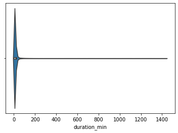

```python
sb.violinplot(data=trip_data_clean, x='duration_min')
```

**Observation**: Long tail on the right side of the distribution. Needs further cleanup of outliers.

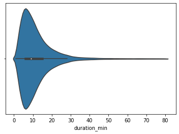

```python
# Focus on the main distribution
trip_data_clean.drop(trip_data_clean[trip_data_clean['duration_min'] > 80].index, inplace=True)

# Check cleaned results
sb.violinplot(data=trip_data_clean, x='duration_min')
```

```python
trip_data_clean['duration_min'].describe()
```

```
count    507344.000000
mean         11.807220
std           9.696243
min           1.000000
25%           6.000000
50%           9.000000
75%          15.000000
max          80.000000
Name: duration_min, dtype: float64
```

### Exploration: user_type

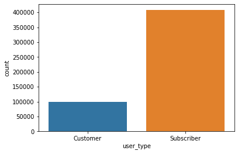

```python
sb.countplot(data=trip_data_clean, x='user_type')
```

**Observation**: Roughly 20% are customers, the rest are subscribers.

### Exploration: start_month

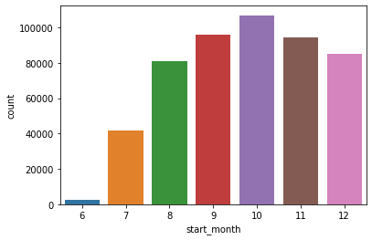

```python
sb.countplot(data=trip_data_clean, x='start_month')
```

**Observation**: October had the most trips per month.

### Exploration: start_station

Reference: https://stackoverflow.com/questions/46623583/seaborn-countplot-order-categories-by-count

**First approach:** Visualize stations count plot

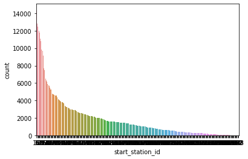

```python
sb.countplot(data=trip_data_clean, x='start_station_id', order=trip_data_clean['start_station_id'].value_counts().index)
```

**Observation**: Need further trimming of the tail

```python
# Filter out less visited stations

# Rference: https://stackoverflow.com/questions/49735683/python-removing-rows-on-count-condition
trip_data_filter = trip_data_clean.groupby('start_station_id').filter(lambda x: len(x) > 6000)
```

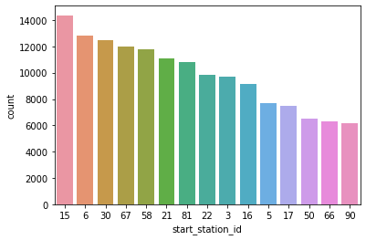

```python
sb.countplot(data=trip_data_filter, x='start_station_id', order=trip_data_filter['start_station_id'].value_counts().index)
```

**Observation**: Still doesn't provide much insight. Trying second approach below.

**Second approach:**

1. Visualize stations with geo locations and sizes.
2. Print list of top 10 station names.

```python
# Reference:
# 1.https://stackoverflow.com/questions/52010388/value-counts-on-multiple-columns-with-groupby
# 2.https://stackoverflow.com/questions/20461165/how-to-convert-index-of-a-pandas-dataframe-into-a-column

# Creating dataframe for visualization
trip_data_station = trip_data_clean.groupby(["start_station_longitude", "start_station_latitude"]).agg({'start_station_id': 'value_counts'})

# Reset index and column names
trip_data_station.reset_index(level=['start_station_longitude','start_station_latitude'], inplace=True)
trip_data_station.rename(columns={"start_station_id": "start_station_counts"}, inplace=True)
trip_data_station.reset_index(level=['start_station_id'], inplace=True)
```

```python
# View created dataframe
trip_data_station.sort_values(by=['start_station_counts'], ascending=False)
```

|  | start_station_id | start_station_longitude | start_station_latitude | start_station_counts |
| --- | --- | --- | --- | --- |
| 110 | 15 | -122.394203 | 37.795392 | 14360 |
| 81 | 6 | -122.403234 | 37.804770 | 12820 |
| 104 | 30 | -122.395282 | 37.776598 | 12450 |
| 103 | 67 | -122.395526 | 37.776639 | 11987 |
| 48 | 58 | -122.417385 | 37.776619 | 11778 |
| ... | ... | ... | ... | ... |
| 260 | 294 | -121.884559 | 37.327581 | 11 |
| 159 | 340 | -122.270582 | 37.849735 | 6 |
| 242 | 292 | -121.896966 | 37.344882 | 5 |
| 177 | 339 | -122.266438 | 37.800002 | 2 |
| 196 | 268 | -122.261578 | 37.857490 | 1 |

272 rows × 4 columns

[figure not shown]

```python
# Visualization through longitude and latitude

# Reference: https://www.bigendiandata.com/2017-06-27-Mapping_in_Jupyter/

# Load image of bay area
bay_img = mpimg.imread('bay.png')

# Scatter plot
trip_data_station.plot(kind="scatter", x="start_station_longitude", y="start_station_latitude",
    s=trip_data_station['start_station_counts']/50, label="counts",
    c='start_station_counts', cmap=plt.get_cmap("jet"),
    colorbar=True, alpha=0.3, figsize=(12,10),
)

# Set image extent
plt.imshow(bay_img, extent=[-122.654377, -121.764004, 37.247629, 37.908477], alpha=0.7)

plt.legend()
plt.show()
```

```python
# Print out top 10 busiest station names

# Reference:
# 1. https://re-thought.com/pandas-value_counts/
# 2. https://stackoverflow.com/questions/36684013/extract-column-value-based-on-another-column-pandas-dataframe

start_station_counts = trip_data_clean['start_station_id'].value_counts().to_frame()

for i in range(10):
    print(i+1,':', trip_data_clean.loc[trip_data_clean['start_station_id'] == start_station_counts.index[i], 'start_station_name'].iloc[0])
```

```
1 : San Francisco Ferry Building (Harry Bridges Plaza)
2 : The Embarcadero at Sansome St
3 : San Francisco Caltrain (Townsend St at 4th St)
4 : San Francisco Caltrain Station 2  (Townsend St at 4th St)
5 : Market St at 10th St
6 : Montgomery St BART Station (Market St at 2nd St)
7 : Berry St at 4th St
8 : Howard St at Beale St
9 : Powell St BART Station (Market St at 4th St)
10 : Steuart St at Market St
```

**Observation**: From the visualization and the list of stations names, we can see clearly that the most busy stations are in the SF downtown area.

### Discuss the distribution(s) of your variable(s) of interest. Were there any unusual points? Did you need to perform any transformations?

1. The variable 'duration_sec' is not normally distributed. I transformed the variable unit from seconds to minutes for easier interpretation.
2. The variable 'start_month' has distribution that is close to normal distribution so no further transformation was needed.
3. THe variable 'start_station_id' had a skewed distribution. The observation matches the visualization of station locations.

## Bivariate Exploration

### 1. The busiest hours in a month (Day vs Hour)

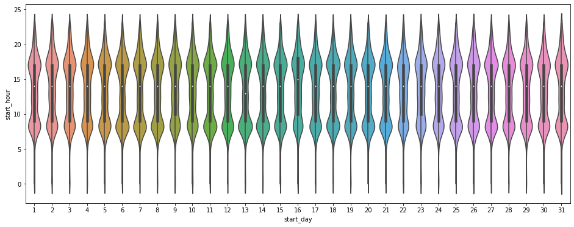

```python
fig, ax = plt.subplots(figsize=(16,6))
sb.violinplot(data = trip_data_clean, x = 'start_day', y = 'start_hour');
```

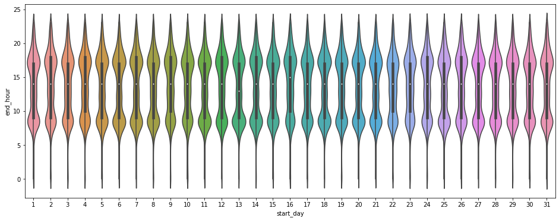

```python
fig, ax = plt.subplots(figsize=(16,6))
sb.violinplot(data = trip_data_clean, x = 'start_day', y = 'end_hour');
```

**Observation**: The busiest hours are pretty much consistent throughout the month with rush hours occuring around 8AM and 5PM.

### 2. The month that has longest average trips (Month vs Duration)

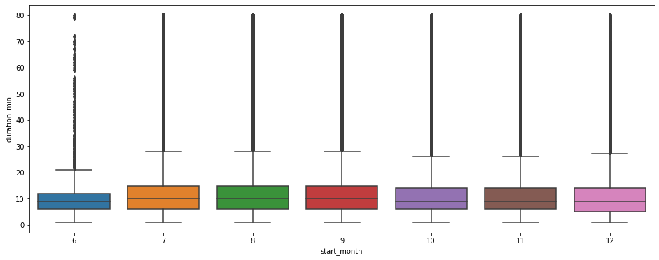

```python
fig, ax = plt.subplots(figsize=(16,6))
sb.boxplot(data = trip_data_clean, x = 'start_month', y = 'duration_min');
```

**Observation**: Overall similar distribution of durations with August and September having slightly higher mean than others.

### 3. User behavior: start/end hours

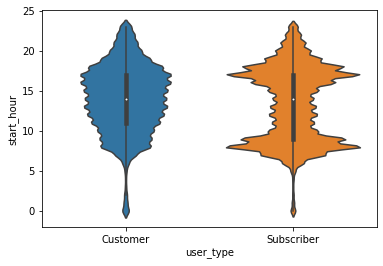

```python
sb.violinplot(data = trip_data_clean, x = 'user_type', y = 'start_hour');
```

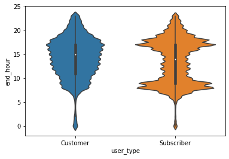

```python
sb.violinplot(data = trip_data_clean, x = 'user_type', y = 'end_hour');
```

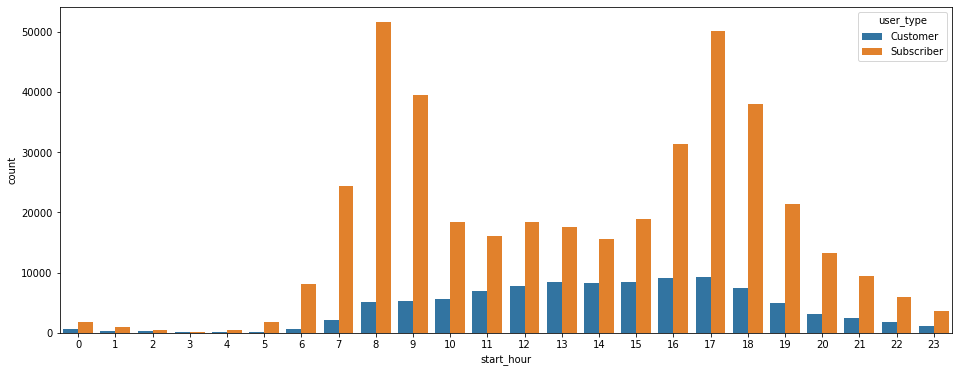

```python
fig, ax = plt.subplots(figsize=(16,6))
sb.countplot(data = trip_data_clean, x = 'start_hour', hue = 'user_type');
```

**Observation**: Subscribers use the bikes the most around rush hour while the customers have no outstanding peaks of usage throughout the day.

### 4. User behavior: duration

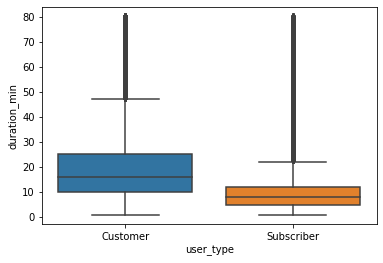

```python
sb.boxplot(data = trip_data_clean, x = 'user_type', y = 'duration_min');
```

**Observation**: Subscribers on average has shorter rides (8 mins) comparing to the customers (15 mins).

### 5. User behavior: monthly number of rides

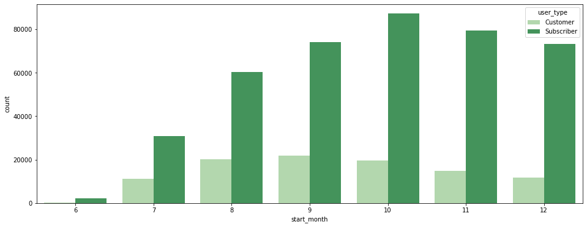

```python
fig, ax = plt.subplots(figsize=(16,6))
sb.countplot(data = trip_data_clean, x = 'start_month', hue = 'user_type', palette = 'Greens');
```

**Observation**: Even though the number of rides for subscribers are 4~5 times more than the customers, the shape of distribution are similar.

### Did you observe any interesting relationships between the other features (not the main feature(s) of interest)?

1. Overall trend of number of rides through the months are similar when comparing subscribers to customers. Even though the number of rides for subscribers are 4~5 times more than the customers, most rides happened between September and November for both of the user groups.

## Multivariate Exploration

### First glance: sample dataset to show less data points

```python
trip_data_sampled = trip_data_clean.sample(800)
```

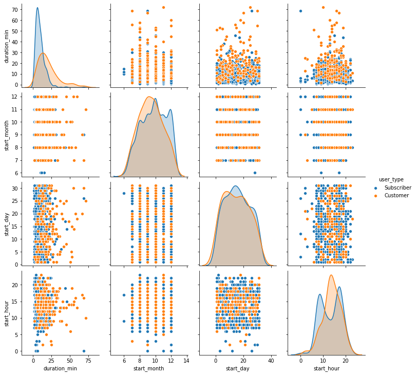

```python
sb.pairplot(trip_data_sampled,
    x_vars=["duration_min", "start_month", "start_day", "start_hour"],
    y_vars=["duration_min", "start_month", "start_day", "start_hour"], hue="user_type")
```

**Observation**: Hard to observe correlations with the high density scatter plots. Going to try FacetGrid below.

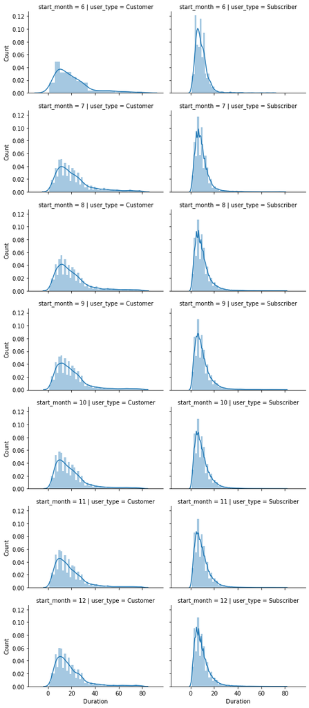

```python
# Reference:
# 1. https://www.kaggle.com/residentmario/faceting-with-seaborn
# 2. https://seaborn.pydata.org/generated/seaborn.distplot.html

g = sb.FacetGrid(trip_data_clean, row = 'start_month',col='user_type', height=2.5, aspect=1.5)
g.map(sb.distplot, 'duration_min')
g.set_axis_labels("Duration", "Count")
```

**Observation**: Better detailed look at the correlation of the three represented variables. But this is still not the best form for comparing data efficiently.

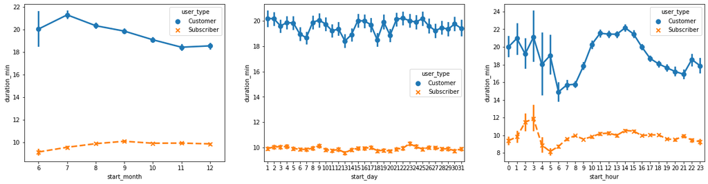

```python
# Explore point plots

# Reference:
# 1. https://seaborn.pydata.org/generated/seaborn.pointplot.html#seaborn.pointplot
# 2. https://stackoverflow.com/questions/38082602/plotting-multiple-different-plots-in-one-figure-using-seaborn

fig, axs = plt.subplots(ncols = 3, figsize = (21,5))

sb.pointplot(x="start_month", y="duration_min", hue="user_type",
                   data=trip_data_clean,
                   markers=["o", "x"],
                   linestyles=["-", "--"], ax=axs[0])
sb.pointplot(x="start_day", y="duration_min", hue="user_type",
                   data=trip_data_clean,
                   markers=["o", "x"],
                   linestyles=["-", "--"], ax=axs[1])
sb.pointplot(x="start_hour", y="duration_min", hue="user_type",
                   data=trip_data_clean,
                   markers=["o", "x"],
                   linestyles=["-", "--"], ax=axs[2])
```

**Observation**:

1. Customers on average have longer trips each month comparing to the subscribers. The trips are especially longer for the summer break months (June, July, and August).
2. On daily average, customers have longer trips than subscribers as well.
3. Customers have the longest rides when the bikes are checked out at noon. On the other hand, subscribers have a relative consistent ride duration through the whole day.

### Talk about some of the relationships you observed in this part of the investigation. Were there features that strengthened each other in terms of looking at your feature(s) of interest?

1. Customers on average have longer trips each month comparing to the subscribers. The trips are especially longer for the summer break months (June, July, and August).
2. Customers tend to have the longest rides when the bikes are checked out around noon. On the other hand, subscribers have a relative consistent ride duration through the whole day.